# R practice: Linear Regression

EWHA-GSIS Computational Social Science Workshop

2022-11-19

# Getting started

### Install R and RStudio

To install R on your computer, go to the website of R http://www.r-project.org/ and install it. To use RStudio layout, go to http://www.rstudio.org/ and download it.

### Working directory

You can check the folder on your computer in which you are currently working.

```r
getwd()
```

```
## [1] "/Users/donghwan/Dropbox/Teaching/20221119_Ewha_GSIS_LM"
```

Type in the command window: `setwd("Your directory name")`

### Packages

There are many packages available on the website. If you want to install and use a package (for example, the package named “ggplot2”)

- Install the package:type `install.packages("ggplot2")`
- Load the package: type `library("ggplot2")` in the command window.

# Some Examples of R commands

$>$ Indicate the prompt at the start of new line

$\#$ Comment operator

$<-$ Assignment operator

$==$ Boolean equality operator

Ex.

```r
x<-5     # assign the value 5 to x
x==5    # returns TRUE
```

```
## [1] TRUE
```

```r
x = 6    # same to <-
x==5    # returns FALSE
```

```
## [1] FALSE
```

### Arithmatic operator

```r
3+3
```

```
## [1] 6
```

```r
17/3
```

```
## [1] 5.666667
```

```r
2^3
```

```
## [1] 8
```

```r
17%/%3
```

```
## [1] 5
```

```r
17%%3
```

```
## [1] 2
```

```r
5/2
```

```
## [1] 2.5
```

### Logical operator (return TRUE or FALSE)

```r
a<-10; b<-5
a>b
```

```
## [1] TRUE
```

```r
a!=5
```

```
## [1] TRUE
```

```r
(5>4)&(8>10)
```

```
## [1] FALSE
```

### Basic mathematical functions

```r
sqrt(16); abs(-2); log(10); exp(2)
```

```
## [1] 4
```

```
## [1] 2
```

```
## [1] 2.302585
```

```
## [1] 7.389056
```

```r
floor(4.9); ceiling(4.1); round(1.583,3)
```

```
## [1] 4
```

```
## [1] 5
```

```
## [1] 1.583
```

### Vectors

```r
x<-c(1,2,3,4,5); y<-c(1:10); z<-rep(1,5);
x2<-seq(1,9,by=2); abc<-c("LEE","KIM","PARK");
x3<-c(x,y);
length(x); min(x); max(x); sum(x); prod(x)
```

```
## [1] 5
```

```
## [1] 1
```

```
## [1] 5
```

```
## [1] 15
```

```
## [1] 120
```

```r
x+x2 # vector plus vector
```

```
## [1]  2  5  8 11 14
```

```r
x[3]; x[3:4]; x[-2] # specific element of vector
```

```
## [1] 3
```

```
## [1] 3 4
```

```
## [1] 1 3 4 5
```

### Matrices

```r
X<-matrix(c(1:10),5,2)
X2<-matrix(c(1:10),5,2,byrow=TRUE)

dim(X); t(X); t(X)%*%X; solve(t(X)%*%X)
```

```
## [1] 5 2
```

```
##      [,1] [,2] [,3] [,4] [,5]
## [1,]    1    2    3    4    5
## [2,]    6    7    8    9   10
```

```
##      [,1] [,2]
## [1,]   55  130
## [2,]  130  330
```

```
##        [,1]   [,2]
## [1,]  0.264 -0.104
## [2,] -0.104  0.044
```

```r
X[,1]; X[2:3,]; X[3,2]
```

```
## [1] 1 2 3 4 5
```

```
##      [,1] [,2]
## [1,]    2    7
## [2,]    3    8
```

```
## [1] 8
```

```r
x1<-rep(1,5)
x2<-c(1,2,3,4,5)

X<-cbind(x1,x2)
X2<-rbind(x1,x2)

diag(1:5); diag(5)
```

```
##      [,1] [,2] [,3] [,4] [,5]
## [1,]    1    0    0    0    0
## [2,]    0    2    0    0    0
## [3,]    0    0    3    0    0
## [4,]    0    0    0    4    0
## [5,]    0    0    0    0    5
```

```
##      [,1] [,2] [,3] [,4] [,5]
## [1,]    1    0    0    0    0
## [2,]    0    1    0    0    0
## [3,]    0    0    1    0    0
## [4,]    0    0    0    1    0
## [5,]    0    0    0    0    1
```

### Data frame

```r
Y<-c(1,2,3,4)
X<-matrix(c(1,1,1,1,1.2,1.5,2,2.5),4,2)

Data<-data.frame(X,Y)
Data
```

```
##   X1  X2 Y
## 1  1 1.2 1
## 2  1 1.5 2
## 3  1 2.0 3
## 4  1 2.5 4
```

### Plots

R can make various plots:

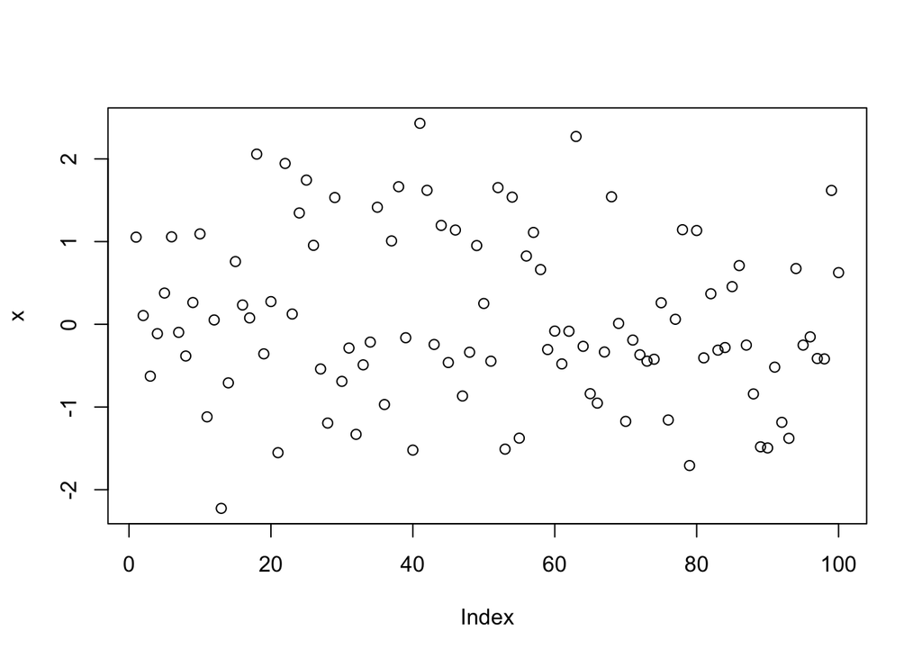

```r
x<-rnorm(100) ## random number generation from N(0,1)
plot(x)
```

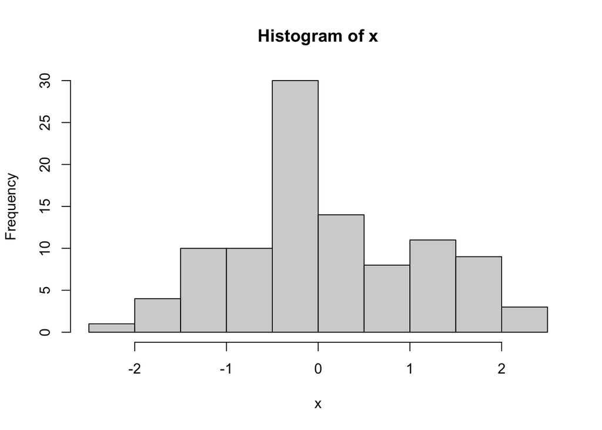

```r
hist(x)
```

# Regression: Statistical modeling

## Regression?

Francis Galton: “Regress (toward the mean)”

- The concept of regression comes from genetics and was popularized by Sir Francis Galton during the late 19th century with the publication of “Regression towards mediocrity in hereditary stature”.
- Galton observed that extreme characteristics (e.g., height) in parents are not passed on completely to their offspring. Rather, the characteristics in the offspring regress towards a mediocre point (a point which has since been identified as the mean) (from *Wikipedia* }
- Regression (in modern sense) : Statistical methodology for modeling a functional relationship between **predictor** variable (input, independent variable) and **response** variable (outcome, dependent variable) Ex. profit - advertising rate, stock price - weather, etc.

#### Main goals:

1. Understanding and Finding the relationship between predictor and response (**Estimation**)
2. Predicting the future response with the new observed predictor (**Prediction**)

#### Basic concepts

Suppose that we observe the predictor $X$ and response $Y$. We want to construct a reasonable function such that
$$Y \approx f(X)$$
However, in real world, there is noisy. We want to establish
$$Y = f(X) + \epsilon$$

A regression model is a formal means of expressing the two essential ingredients of a statistical relation:

1. A tendency of the response variable $Y$ to vary with the predictor variable $X$ in a systematic fashion.
2. A scattering of points around the curve of statistical relationship.

#### Linear Regression model

Simple form of $f(X)?$ $f(X) = \beta_0 + \beta_1 X$ (regression line)

$$Y = \beta_0 + \beta_1 X + \epsilon$$

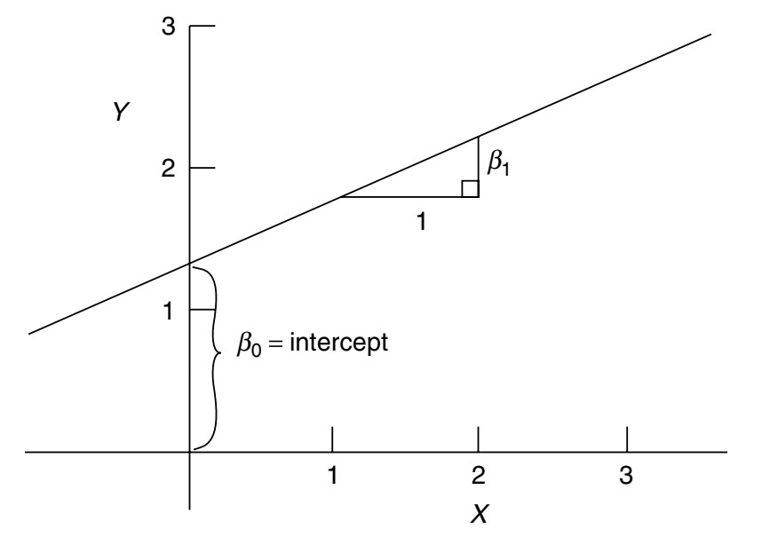

Fig 1. Graph of $E(Y|X=x)=\beta_0 + \beta_1x$

## Example: Simple linear regression

```r
library(ggplot2)
library(modelr)
options(na.action = na.warn)
## sim1: synthetic data
head(sim1)
```

```
## # A tibble: 6 × 2
##       x     y
##   <int> <dbl>
## 1     1  4.20
## 2     1  7.51
## 3     1  2.13
## 4     2  8.99
## 5     2 10.2
## 6     2 11.3
```

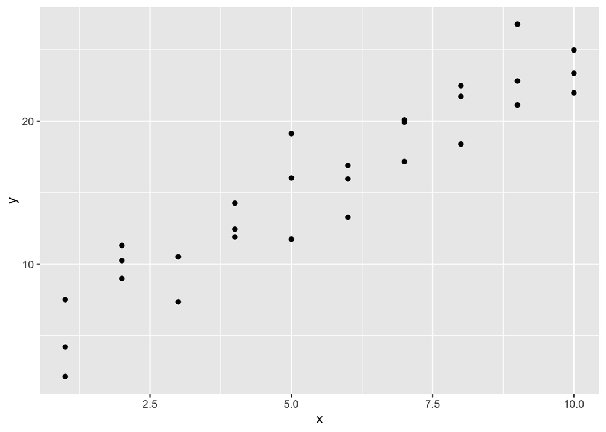

```r
ggplot(sim1, aes(x,y)) + geom_point()
```

> **Question 1**: How to construct the (optimal) regression line?

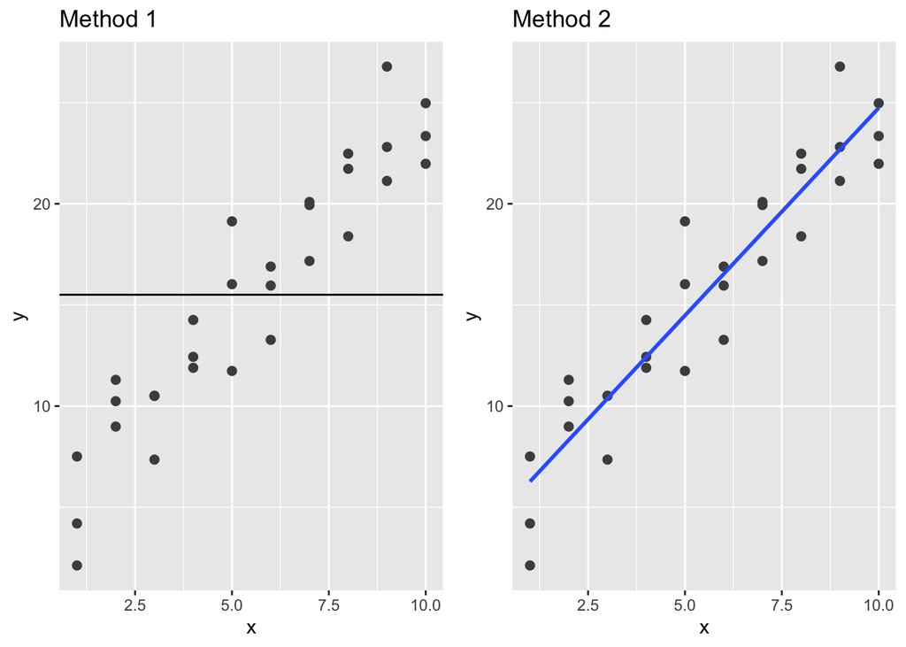

```r
library(gridExtra)
g1=ggplot(sim1, aes(x, y)) + geom_point(size = 2, colour = "grey30") + geom_abline(intercept = mean(sim1$y), slope = 0) + ggtitle("Method 1")
g2 = ggplot(sim1, aes(x,y)) + geom_point(size = 2, colour = "grey30") + geom_smooth(method = "lm", se= FALSE) + ggtitle("Method 2")

grid.arrange(g1,g2,ncol=2)
```

$\Rightarrow$ Method 2 is better? Yes!

#### Ordinary Least Square (OLS) method

We find the unknown parameters $\beta_0$ and $\beta_1$ by minimizing
$$Q = \sum_{i=1}^n [Y_i - (\beta_0 + \beta_1 X_i) ]^2$$

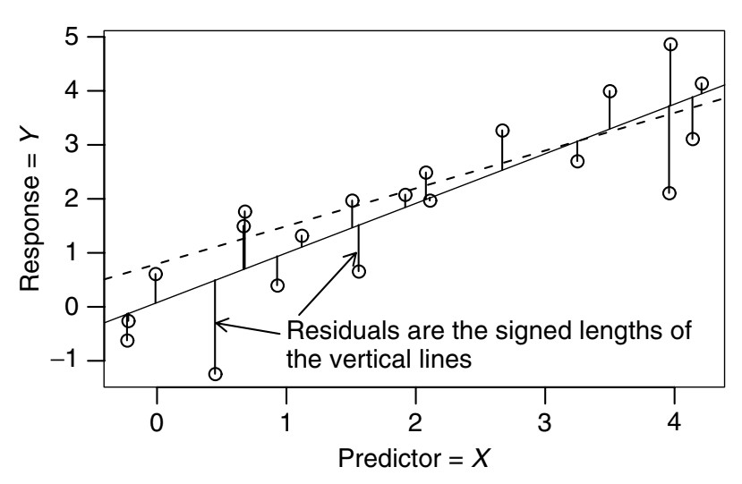

Fig 2. OLS estimation

#### Optimal estimates

```r
fit<- lm(y~x, data=sim1)
summary(fit)$coef
```

```
##             Estimate Std. Error   t value     Pr(>|t|)
## (Intercept) 4.220822  0.8688261  4.858074 4.088263e-05
## x           2.051533  0.1400240 14.651295 1.173451e-14
```

#### Fitting equation

```r
b0 <- round(fit$coefficients[[1]],2)
b1 <- round(fit$coefficients[[2]],2)

eq <- paste("y = ",b0," + ", b1, "x ")
eq
```

```
## [1] "y =  4.22  +  2.05 x "
```

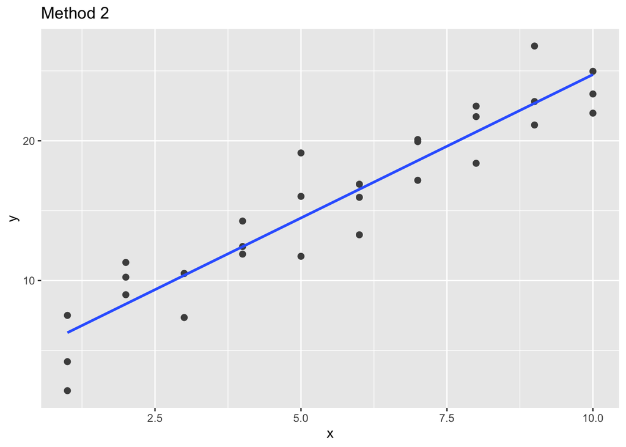

```r
g2
```

## Example: Gapminder dataset

We will use a subset of the gapminder data (https://www.gapminder.org/data/, https://cran.r-project.org/web/packages/gapminder/README.html). At the website https://www.gapminder.org/data/, you can collect more variables.

```r
library(gapminder)
library(ggplot2)
library(dplyr)
library(MASS)
library(leaps)
```

```r
head(gapminder)
```

```
## # A tibble: 6 × 6
##   country     continent  year lifeExp      pop gdpPercap
##   <fct>       <fct>     <int>   <dbl>    <int>     <dbl>
## 1 Afghanistan Asia       1952    28.8  8425333      779.
## 2 Afghanistan Asia       1957    30.3  9240934      821.
## 3 Afghanistan Asia       1962    32.0 10267083      853.
## 4 Afghanistan Asia       1967    34.0 11537966      836.
## 5 Afghanistan Asia       1972    36.1 13079460      740.
## 6 Afghanistan Asia       1977    38.4 14880372      786.
```

```r
str(gapminder)
```

```
## tibble [1,704 × 6] (S3: tbl_df/tbl/data.frame)
##  $ country  : Factor w/ 142 levels "Afghanistan",..: 1 1 1 1 1 1 1 1 1 1 ...
##  $ continent: Factor w/ 5 levels "Africa","Americas",..: 3 3 3 3 3 3 3 3 3 3 ...
##  $ year     : int [1:1704] 1952 1957 1962 1967 1972 1977 1982 1987 1992 1997 ...
##  $ lifeExp  : num [1:1704] 28.8 30.3 32 34 36.1 ...
##  $ pop      : int [1:1704] 8425333 9240934 10267083 11537966 13079460 14880372 12881816 13867957 16317921 22227415 ...
##  $ gdpPercap: num [1:1704] 779 821 853 836 740 ...
```

The variables in the dataset:

- country : Country name
- continent : Continent
- year : Year
- lifeExp : Life expectancy at birth, in years pop : Population
- gdpPercap : GDP per capita (US$, inflation-adjusted)

### Filtering:

```r
europe= gapminder %>% filter(continent=="Europe" & year==2007)
head(as.data.frame(europe))
```

```
##                  country continent year lifeExp      pop gdpPercap
## 1                Albania    Europe 2007  76.423  3600523  5937.030
## 2                Austria    Europe 2007  79.829  8199783 36126.493
## 3                Belgium    Europe 2007  79.441 10392226 33692.605
## 4 Bosnia and Herzegovina    Europe 2007  74.852  4552198  7446.299
## 5               Bulgaria    Europe 2007  73.005  7322858 10680.793
## 6                Croatia    Europe 2007  75.748  4493312 14619.223
```

> **Question 2**: Can we explain (or predict) the life expectancy using gdpPercap variable?

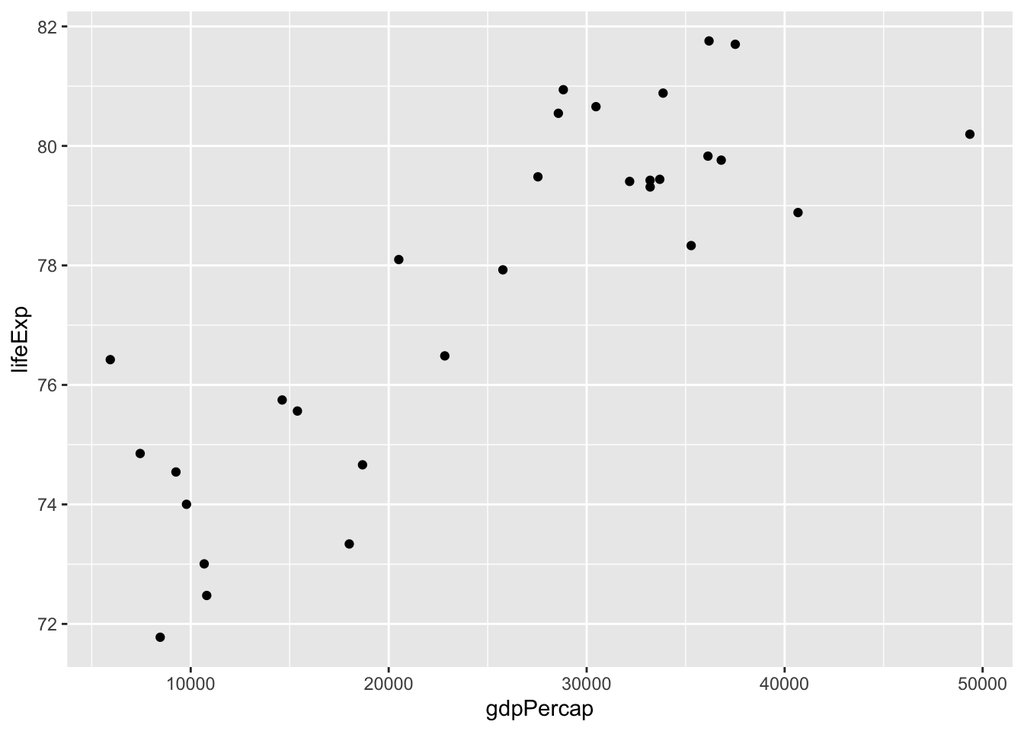

```r
europe %>% ggplot(aes(x=gdpPercap, y=lifeExp))+geom_point()
```

### Linear regression fit:

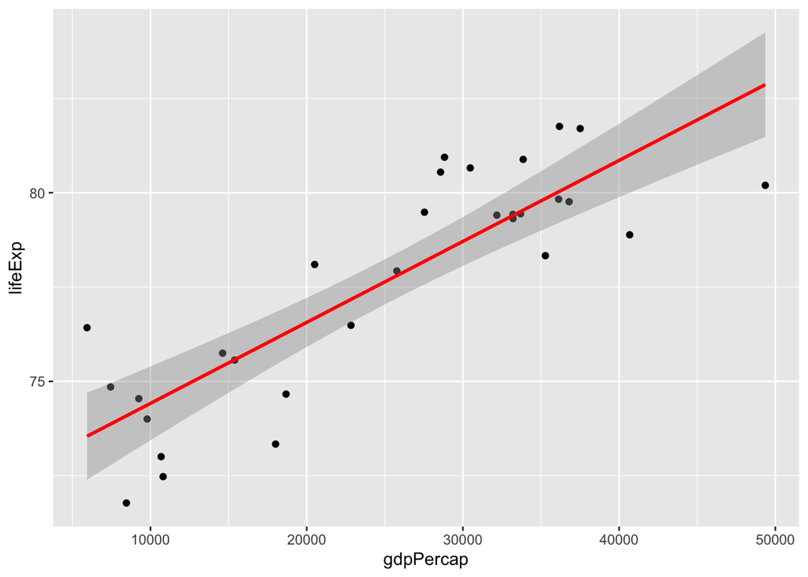

```r
europe %>% ggplot(aes(x=gdpPercap, y=lifeExp))+geom_point()+
  stat_smooth(method = "lm", col = "red")
```

```r
fit <- lm(lifeExp~gdpPercap, data=europe)
summary(fit)
```

```
##
## Call:
## lm(formula = lifeExp ~ gdpPercap, data = europe)
##
## Residuals:
##      Min       1Q   Median       3Q      Max
## -2.79839 -1.30472  0.00807  1.33443  2.87766
##
## Coefficients:
##              Estimate Std. Error t value Pr(>|t|)
## (Intercept) 7.227e+01  6.942e-01 104.113  < 2e-16 ***
## gdpPercap   2.146e-04  2.514e-05   8.537  2.8e-09 ***
## ---
## Signif. codes:  0 '***' 0.001 '**' 0.01 '*' 0.05 '.' 0.1 ' ' 1
##
## Residual standard error: 1.598 on 28 degrees of freedom
## Multiple R-squared:  0.7225, Adjusted R-squared:  0.7125
## F-statistic: 72.88 on 1 and 28 DF,  p-value: 2.795e-09
```

```r
fit$coefficients[[2]]*10000
```

```
## [1] 2.14634
```

**Interpretation:** We can say: “If the GDP increases by $10,000, life expectancy increases by 2.146 years.”

> **Question 3**: Assume that a new European country has gdpPercap=20,000. Can we predict the lifeExp of this country? How can compute the 95% Prediction interval?

```r
#### predict using new observation : gdpPercap = 20,000
predict.lm(fit, newdata=data.frame(gdpPercap=20,000), interval="prediction")
```

```
##        fit      lwr      upr
## 1 72.27535 68.70755 75.84315
```

## Example: Bike store sales in Europe

Refer https://www.kaggle.com/code/alaaalghmdi/bike-sales-eda-prediction-step-by-step

```r
library(tidyverse)
library(car)
library(dplyr)
library(MASS)

sales = read.csv("Sales.csv")
head(sales)
```

```
##         Date Day    Month Year Customer_Age      Age_Group Customer_Gender
## 1 2013-11-26  26 November 2013           19    Youth (<25)               M
## 2 2015-11-26  26 November 2015           19    Youth (<25)               M
## 3 2014-03-23  23    March 2014           49 Adults (35-64)               M
## 4 2016-03-23  23    March 2016           49 Adults (35-64)               M
## 5 2014-05-15  15      May 2014           47 Adults (35-64)               F
## 6 2016-05-15  15      May 2016           47 Adults (35-64)               F
##     Country            State Product_Category Sub_Category             Product
## 1    Canada British Columbia      Accessories   Bike Racks Hitch Rack - 4-Bike
## 2    Canada British Columbia      Accessories   Bike Racks Hitch Rack - 4-Bike
## 3 Australia  New South Wales      Accessories   Bike Racks Hitch Rack - 4-Bike
## 4 Australia  New South Wales      Accessories   Bike Racks Hitch Rack - 4-Bike
## 5 Australia  New South Wales      Accessories   Bike Racks Hitch Rack - 4-Bike
## 6 Australia  New South Wales      Accessories   Bike Racks Hitch Rack - 4-Bike
##   Order_Quantity Unit_Cost Unit_Price Profit Cost Revenue
## 1              8        45        120    590  360     950
## 2              8        45        120    590  360     950
## 3             23        45        120   1366 1035    2401
## 4             20        45        120   1188  900    2088
## 5              4        45        120    238  180     418
## 6              5        45        120    297  225     522
```

```r
dim(sales)
```

```
## [1] 113036     18
```

The variables in the dataset:

- `Date` : Date of the order
- `Day` : Day of the order
- `Month` : Month of the order
- `Year` : Year of the order
- `Customer_Age` : The Age of customer
- `Age_Group` : Age range for the customer
- `Customer_Gender` : The customer gender
- `Country` : The country where the order was made
- `State` : The state where the order was made
- `Product_Category` : Product category for each order
- `Sub_Category` : Product sub category for each order
- `Product` : The product for each order
- `Order_Quantity` : Quantity of the product
- `Unit_Cost` : Cost of inventory holding cost
- `Unit_Price` : The price of the product
- `Profit` : Net profit of each order
- `Cost` : The sum cost of all product for each order
- `Revenue` : Total revenue of each order

> **Question 4**: Build the regression model to predict `Profit` by using `Year`, `Customer_Age`, `Customer_Gender`, `Country`, `Product_Category`, `Cost` and etc.

```r
fit <- lm(Profit ~Year + Customer_Age + Customer_Gender + Country + Product_Category + Cost ,data = sales)
summary(fit)
```

```
##
## Call:
## lm(formula = Profit ~ Year + Customer_Age + Customer_Gender +
##     Country + Product_Category + Cost, data = sales)
##
## Residuals:
##     Min      1Q  Median      3Q     Max
## -5538.0   -86.4   -27.5    63.9  1931.3
##
## Coefficients:
##                            Estimate Std. Error t value Pr(>|t|)
## (Intercept)              -7.252e+03  9.212e+02  -7.872 3.53e-15 ***
## Year                      3.598e+00  4.573e-01   7.867 3.66e-15 ***
## Customer_Age              4.922e-01  5.141e-02   9.573  < 2e-16 ***
## Customer_GenderM          3.562e+00  1.127e+00   3.161  0.00157 **
## CountryCanada             1.201e+02  2.023e+00  59.392  < 2e-16 ***
## CountryFrance             2.511e+01  2.181e+00  11.514  < 2e-16 ***
## CountryGermany            6.608e+01  2.174e+00  30.391  < 2e-16 ***
## CountryUnited Kingdom     1.105e+02  2.034e+00  54.345  < 2e-16 ***
## CountryUnited States      7.915e+01  1.564e+00  50.598  < 2e-16 ***
## Product_CategoryBikes    -4.470e+01  1.936e+00 -23.087  < 2e-16 ***
## Product_CategoryClothing -7.260e+01  1.633e+00 -44.444  < 2e-16 ***
## Cost                      4.812e-01  8.897e-04 540.782  < 2e-16 ***
## ---
## Signif. codes:  0 '***' 0.001 '**' 0.01 '*' 0.05 '.' 0.1 ' ' 1
##
## Residual standard error: 189.2 on 113024 degrees of freedom
## Multiple R-squared:  0.8263, Adjusted R-squared:  0.8263
## F-statistic: 4.889e+04 on 11 and 113024 DF,  p-value: < 2.2e-16
```

> **Question 5**: Predict the profit with the predictors.

```r
#### predict using new observation : gdpPercap = 20,000
predict.lm(fit, newdata=data.frame(Year=2016, Customer_Age = 30, Customer_Gender ="F",
                                   Country = "Germany", Product_Category="Bikes",
                                   Cost = 500), interval="prediction")
```

```
##        fit       lwr     upr
## 1 278.5725 -92.20797 649.353
```